# act_report

## Report: act_report

### Insights after analyzing data

#### 2. Averagely 25% of the dog predictions are not dog breeds.

Finding percentage value counts for True and False values. True affriming dog breed to being in existence while False tells that the dog breed is non existant. For the first prediction percentage of false values is 26.02, second prediction is 24.89 and third prediction is 27.76.

#### 3. Most of the dogs are in the pupper stage.

Performaing value_counts for each dog_stage shows that puppers are more in numbers than the rest.

#### 4. The doggo have most favorite counts with pupper having the least.

Performing a groupby function of dog_stage by favorite count, doggos have more favourite counts as compared to pupper.

#### 4. In comparison to the number of dogs in each dog stage, the puppers have the highest ratings.

Due to their high numbers the pupper ratings are generally higher than the rest. Below is a Visualization affriming the same.

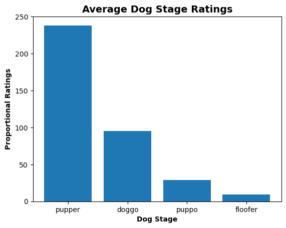